# examples_ET_day03

Label the four transformations:

## Transformation 1

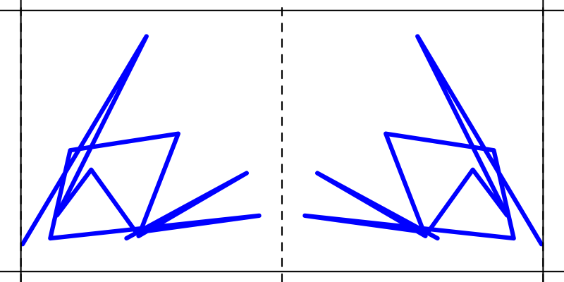

## Transformation 2

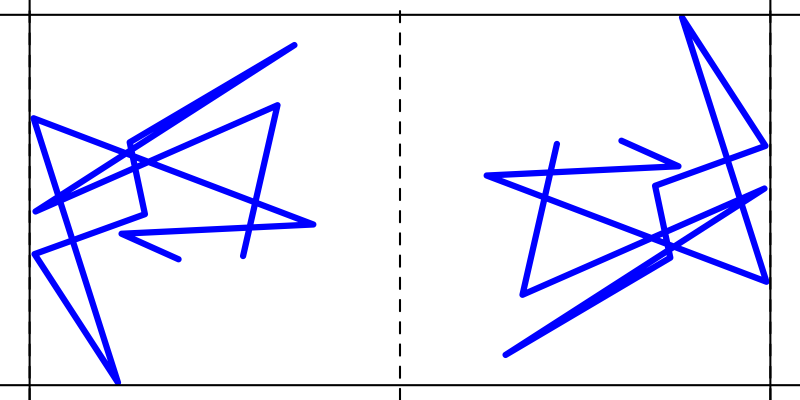

## Transformation 3

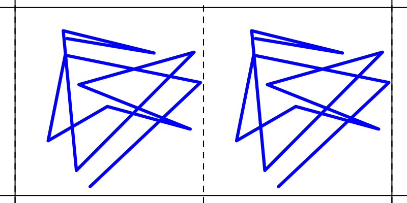

## Transformation 4

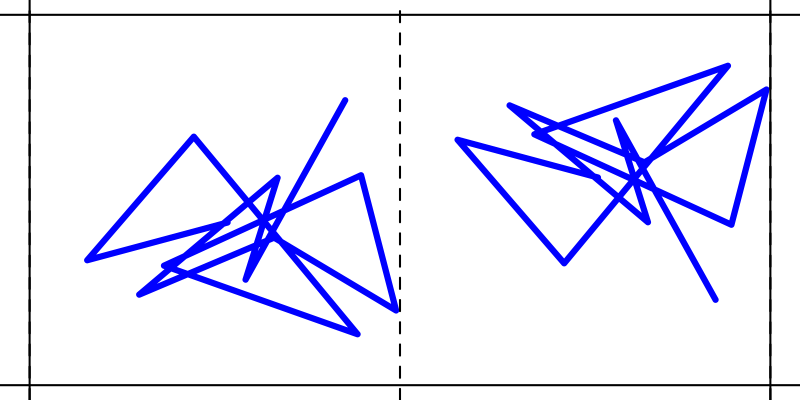

- Transformation 1: mirror.
- Transformation 2: rotation.
- Transformation 3: translation.
- Transformation 4: glide.

4, 2, 1, 3

Label the four transformations:

## Transformation 1

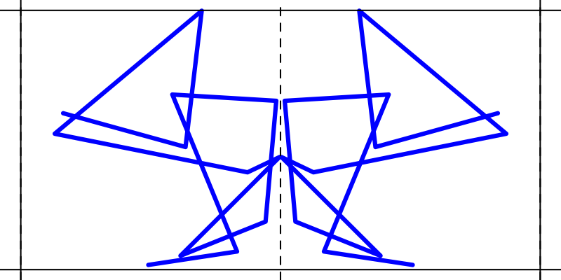

## Transformation 2

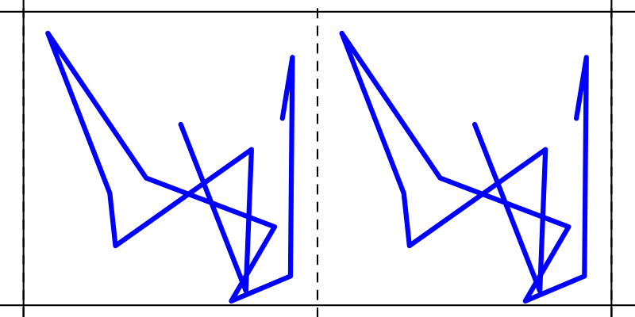

## Transformation 3

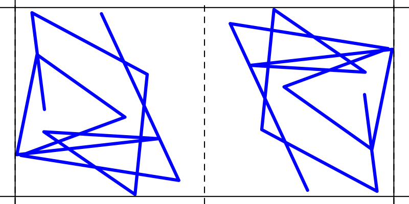

## Transformation 4

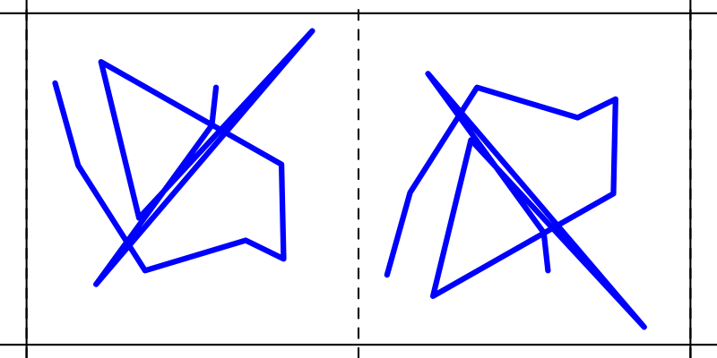

- Transformation 1: mirror.
- Transformation 2: translation.
- Transformation 3: rotation.
- Transformation 4: glide.

4, 1, 2, 3

Label the four transformations:

## Transformation 1

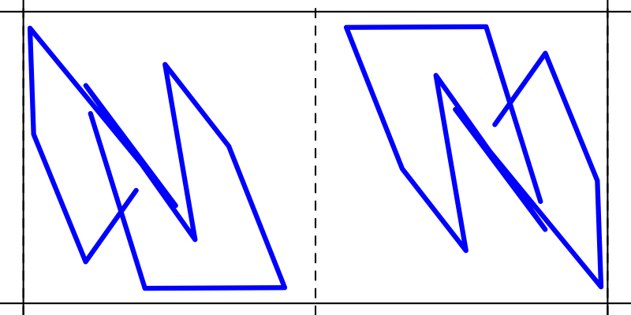

## Transformation 2

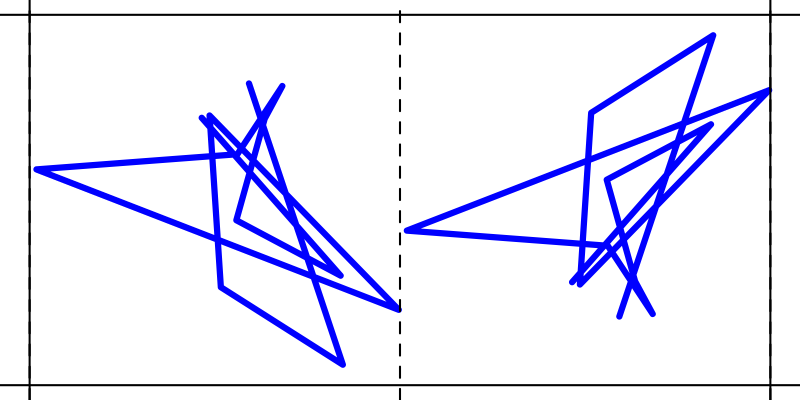

## Transformation 3

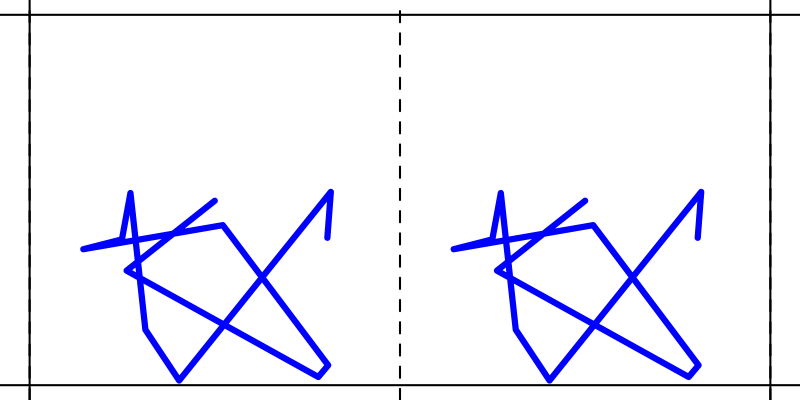

## Transformation 4

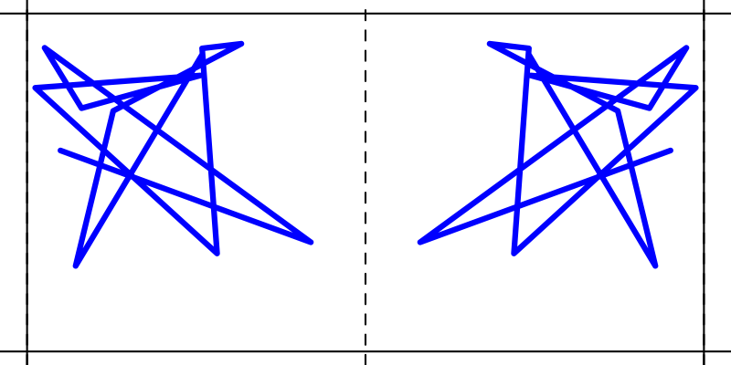

- Transformation 1: rotation.
- Transformation 2: glide.
- Transformation 3: translation.
- Transformation 4: mirror.

2, 3, 1, 4

Label the four transformations:

## Transformation 1

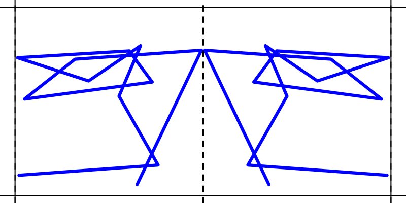

## Transformation 2

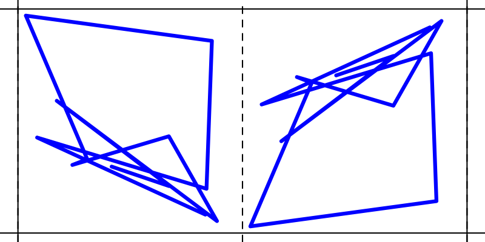

## Transformation 3

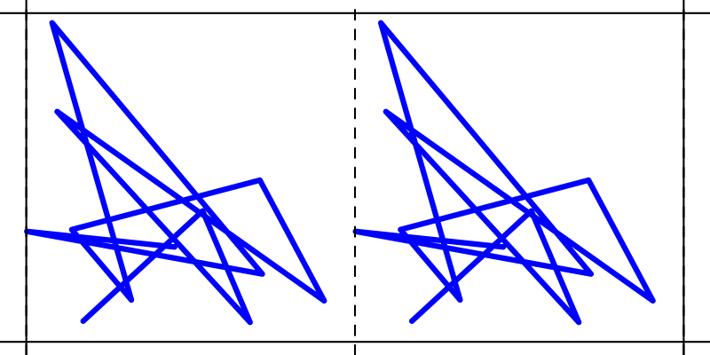

## Transformation 4

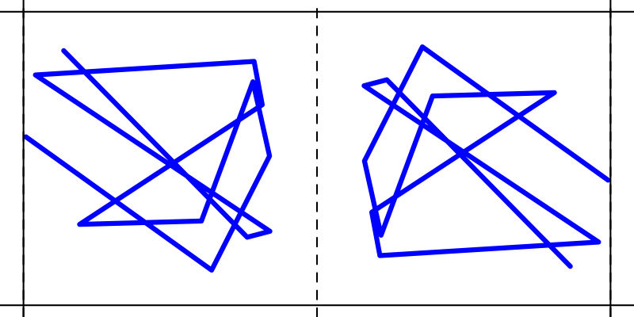

- Transformation 1: mirror.
- Transformation 2: glide.
- Transformation 3: translation.
- Transformation 4: rotation.

4, 3, 1, 2

Label the four transformations:

## Transformation 1

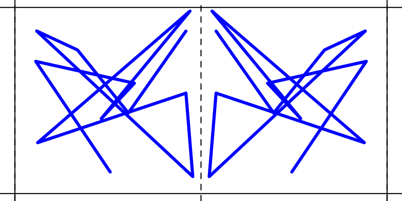

## Transformation 2

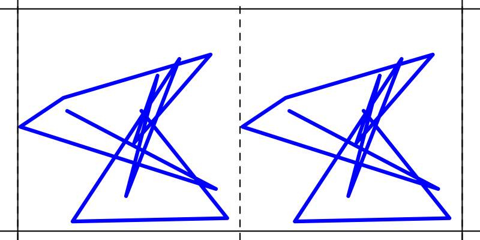

## Transformation 3

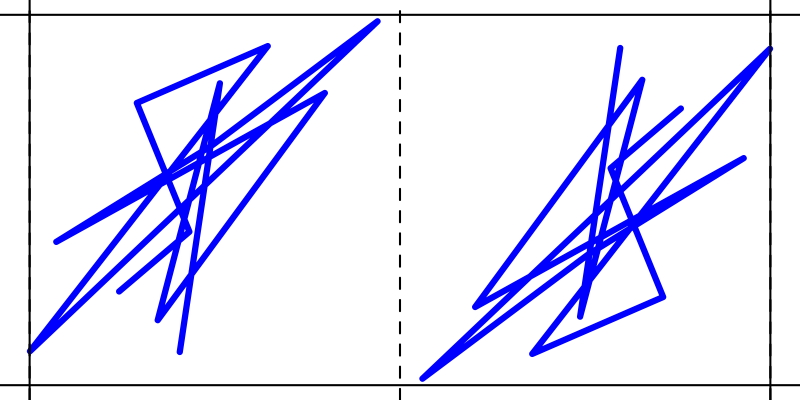

## Transformation 4

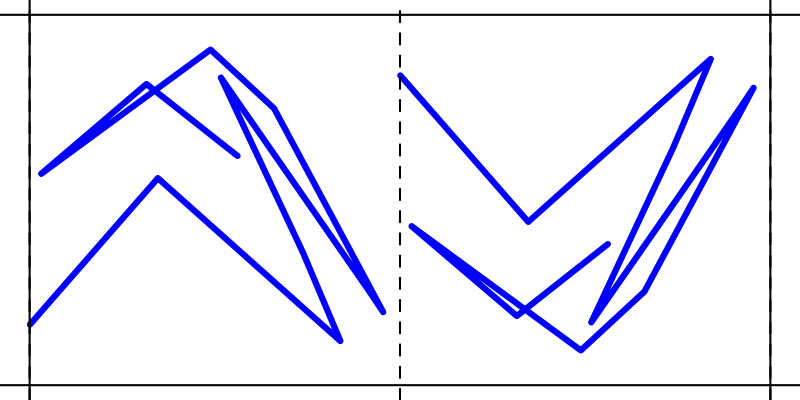

- Transformation 1: mirror.
- Transformation 2: translation.
- Transformation 3: rotation.
- Transformation 4: glide.

4, 1, 2, 3

Label the four transformations:

## Transformation 1

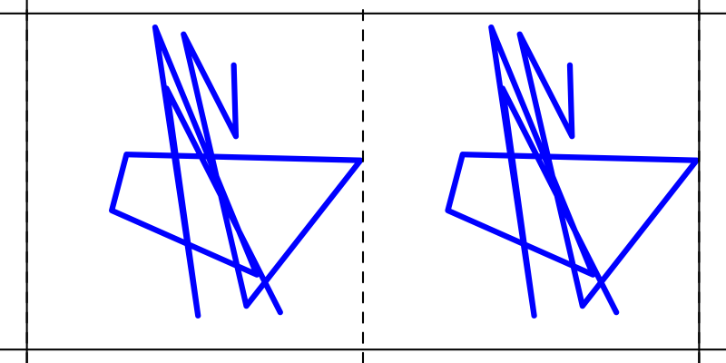

## Transformation 2

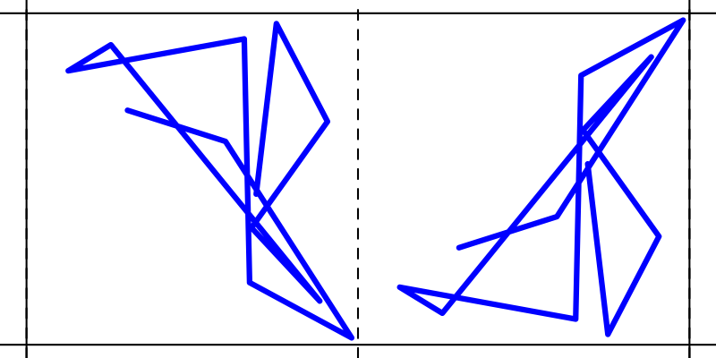

## Transformation 3

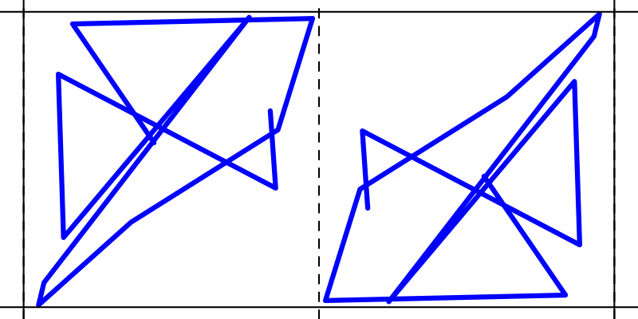

## Transformation 4

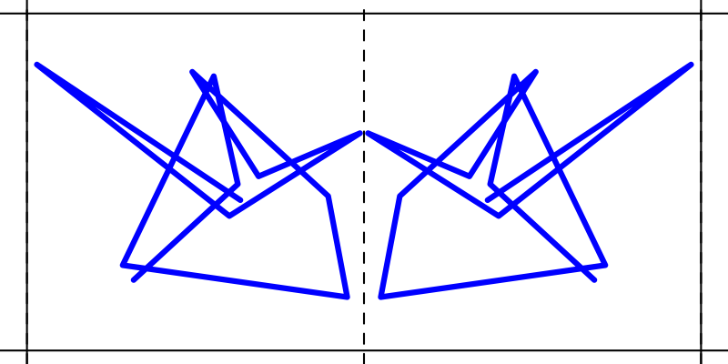

- Transformation 1: translation.
- Transformation 2: glide.
- Transformation 3: rotation.
- Transformation 4: mirror.

1, 3, 2, 4

Label the four transformations:

## Transformation 1

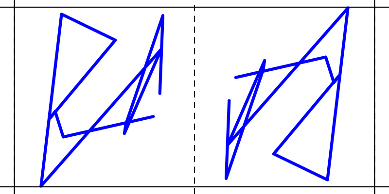

## Transformation 2

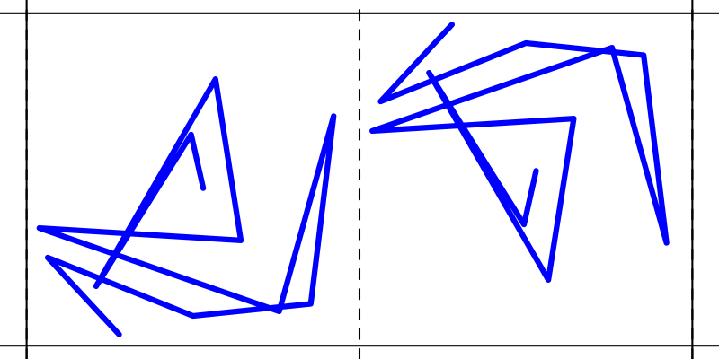

## Transformation 3

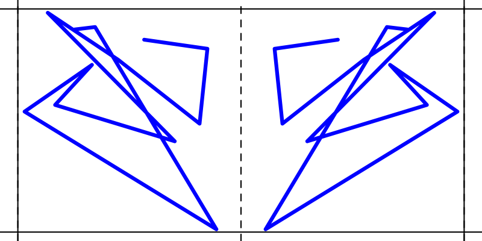

## Transformation 4

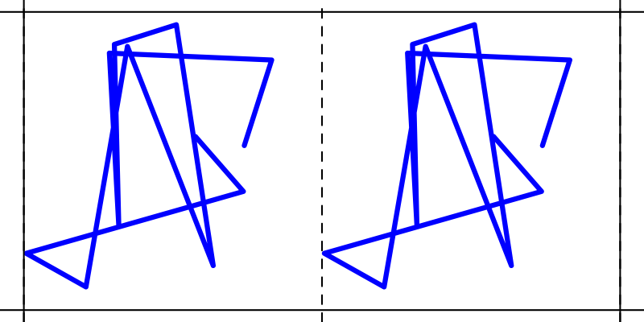

- Transformation 1: rotation.
- Transformation 2: glide.
- Transformation 3: mirror.
- Transformation 4: translation.

2, 3, 4, 1

Label the four transformations:

## Transformation 1

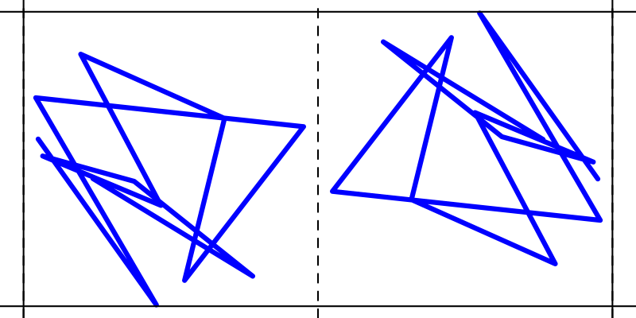

## Transformation 2

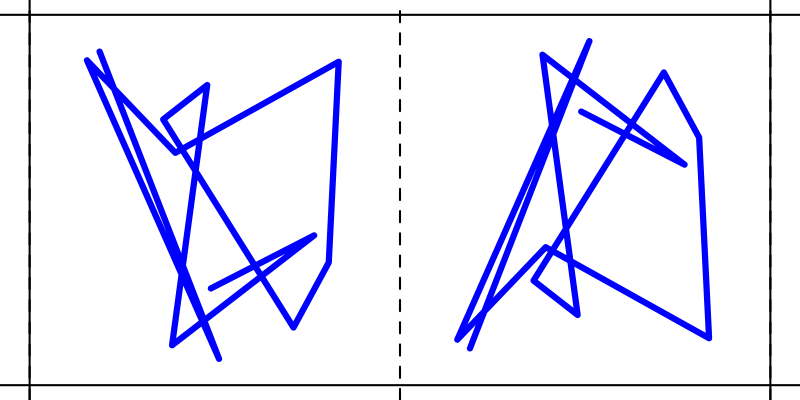

## Transformation 3

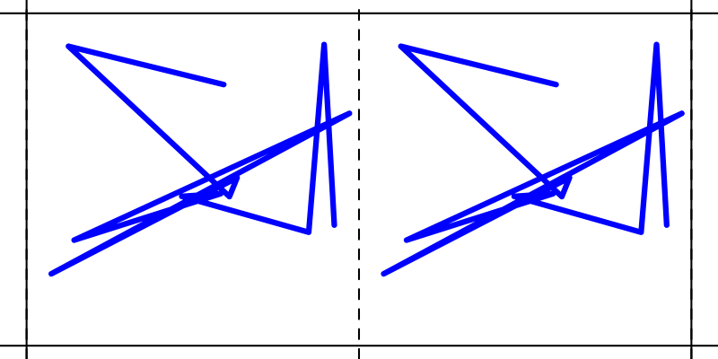